# Explore tumor cell classification with CellAssign

Ally Hawkins

2024-05-30

## Introduction

This notebook looks at classifying tumor cells with `CellAssign` in a Ewing sarcoma sample, SCPCS000494.

We use `CellAssign` with a variety of references:

- A full list of tumor marker genes only.
- Tumor marker genes and non-tumor marker genes from [Visser et al.](https://doi.org/10.1158/2767-9764.CRC-23-0027) specified in the supplemental methods.

We then compare the results from running `CellAssign` with each reference to the tumor/normal classifications obtained from looking only at marker genes. We also look at marker gene expression in the assigned cells.

## Setup

```r
suppressPackageStartupMessages({
  # load required packages
  library(SingleCellExperiment)
  library(ggplot2)
})
# The base path for the OpenScPCA repository, found by its (hidden) .git directory
repository_base <- rprojroot::find_root(rprojroot::is_git_root)

# The current data directory, found within the repository base directory
data_dir <- file.path(repository_base, "data", "current")
sample_dir <- file.path(data_dir, "SCPCP000015", params$sample_id)

# The path to this module
module_base <- file.path(repository_base, "analyses", "cell-type-ewings")
```

```r
# source in helper functions make_jaccard_matrix() and jaccard()
jaccard_functions <- file.path(module_base, "scripts", "utils", "jaccard-functions.R")
source(jaccard_functions)
```

```r
# Input files
sce_filename <- glue::glue("{params$library_id}_processed.rds")
sce_file <- file.path(sample_dir, sce_filename)

tumor_markers_file <- file.path(module_base, "references", "tumor-marker-genes.tsv")
visser_markers_file <- file.path(module_base, "references", "visser-all-marker-genes.tsv")

# output annotations
cellassign_annotations_file <- file.path(params$results_dir, glue::glue("{params$library_id}_cellassign-classifications.tsv"))
```

Define some helper functions for creating a reference matrix and obtaining cell type annotations from `CellAssign` predictions.

```r
# function to get assigned cell type based on max prediction returned by CellAssign
get_celltype_assignment <- function(predictions){

  # if no predictions, assign every cell to NA
  if(length(colnames(predictions)) == 1){
    celltype_assignments <- data.frame(
      barcode = predictions$barcode,
      celltype = NA
    )
  } else {
    # get individual cell type assignments
    # those with the max prediction
    celltype_assignments <- predictions |>
      tidyr::pivot_longer(
        !barcode,
        names_to = "celltype",
        values_to = "score"
      ) |>
      dplyr::group_by(barcode) |>
      dplyr::slice_max(score, n = 1) |>
      dplyr::ungroup()
  }

  return(celltype_assignments)
}
```

```r
# read in processed sce
sce <- readr::read_rds(sce_file)

# read in tumor marker genes table
tumor_markers_df <- readr::read_tsv(tumor_markers_file) |>
  # account for genes being from multiple sources
  dplyr::select(cell_type, ensembl_gene_id, gene_symbol) |>
  dplyr::distinct()
# read in all marker genes
visser_markers_df <- readr::read_tsv(visser_markers_file) |>
  # account for genes being from multiple sources
  dplyr::select(cell_type, ensembl_gene_id, gene_symbol) |>
  dplyr::distinct()
# read in tumor normal classifications
# obtained from manual classification in `01-marker-gene-tumor-classifications.Rmd`
classifications_df <- readr::read_tsv(params$marker_gene_classification)
tumor_predictions <- readr::read_tsv(params$tumor_marker_predictions)
visser_predictions <- readr::read_tsv(params$visser_marker_predictions)
panglao_predictions <- readr::read_tsv(params$panglao_predictions)
```

```r
# check if marker gene annotations are present
if(all(is.na(classifications_df$marker_gene_classification))){
  has_marker_gene <- FALSE
  message("No annotations were available using only marker gene expression.
          Any plots comparing CellAssign to marker gene annotation will be skipped.")
} else {
  has_marker_gene <- TRUE
}
```

## Analysis content

### Run CellAssign with only tumor marker genes

First let’s see if we can use `CellAssign` to classify cells as tumor or normal using just the list of tumor marker genes.

We will read in the predictions file and find the predicted cell type for each cell, either “tumor” or “other”. Then we’ll show a heatmap of the scores for each cell and cell type. Included in that heatmap will be annotation of which cells were classified as tumor or normal using the manual classification.

```r
# get cell type assignments
tumor_celltype_assignments <- get_celltype_assignment(tumor_predictions)

if(all(is.na(tumor_celltype_assignments$celltype))){
  has_tumor_assignments <- FALSE
  message("No CellAssign assignments found for tumor marker genes.")
} else {
 # create a table of assignments
  table(tumor_celltype_assignments$celltype)
  has_tumor_assignments <- TRUE
}
```

```r
# define annotations to use in all heatmaps
if(has_marker_gene){
  # get annotations for heatmaps
  annotation_df <- data.frame(
    marker_gene_classification = classifications_df$marker_gene_classification,
    row.names = classifications_df$barcodes
  )
} else {
  annotation_df <- NULL
}
```

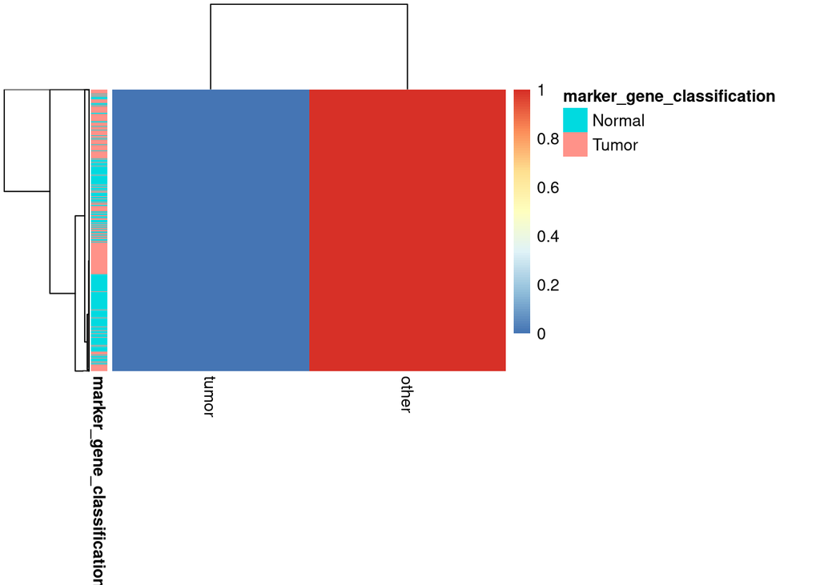

```r
# heatmap of prediction scores
tumor_predictions |>
  tibble::column_to_rownames("barcode") |>
  as.matrix() |>
  pheatmap::pheatmap(show_rownames = FALSE,
                     annotation_row = annotation_df)
```

Let’s also look at the cell annotations on a UMAP and then look at the confusion matrix.

```r
# rename cell type column
tumor_celltype_assignments <- tumor_celltype_assignments |>
  dplyr::rename(cellassign_annotations = celltype)

# create a dataframe to use for plotting with UMAP and cell information
celltype_df <- sce |>
  scuttle::makePerCellDF(use.dimred = "UMAP") |>
  # replace UMAP.1 with UMAP1
  dplyr::rename_with(
        \(x) stringr::str_replace(x, "^UMAP\\.", "UMAP")
      ) |>
  # join with tumor normal
  dplyr::left_join(classifications_df, by = "barcodes") |>
  # join with filtered cell type assignments from cellassign
  dplyr::left_join(tumor_celltype_assignments, by = c("barcodes" = "barcode"))
```

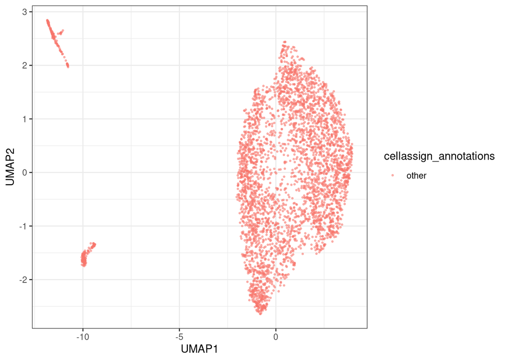

```r
ggplot(celltype_df, aes(x = UMAP1, y = UMAP2, color = cellassign_annotations)) +
  geom_point(size = 0.5, alpha = 0.5) +
  theme_bw()
```

```r
# make sure that we only run if both classes are found in both cell types
if(all(c("other", "tumor") %in% celltype_df$cellassign_annotations) &&
   all(c("Tumor", "Normal") %in% celltype_df$marker_gene_classification)){
  # prep annotations for confusion matrix
  celltype_df <- celltype_df |>
    dplyr::mutate(cellassign_annotations = ifelse(
      # make sure annotations match marker gene annotations
      cellassign_annotations == "tumor", "Tumor", "Normal"
    )) |>
    # make tumor the positive class
    dplyr::mutate(
      cellassign_annotations = forcats::fct_relevel(cellassign_annotations, "Tumor"),
      marker_gene_classification = forcats::fct_relevel(marker_gene_classification, "Tumor")
    )

  caret::confusionMatrix(
    table(
      celltype_df$marker_gene_classification,
      celltype_df$cellassign_annotations)
  )
}
```

To confirm that the cells with tumor cells have higher expression of marker genes, let’s look at the mean expression of marker genes between tumor and other cells as classified by `CellAssign`.

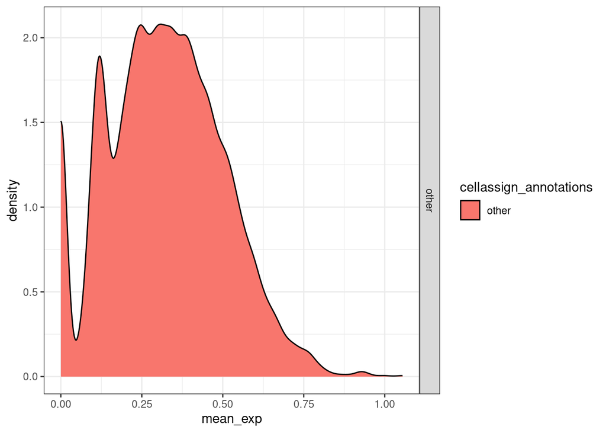

```r
# get marker gene expression
marker_gene_exp <- logcounts(sce[tumor_markers_df$ensembl_gene_id, ]) |>
  as.matrix() |>
  t() |>
  as.data.frame() |>
  tibble::rownames_to_column("barcodes")

marker_gene_exp_df <- celltype_df |>
  dplyr::left_join(marker_gene_exp, by = "barcodes") |>
  tidyr::pivot_longer(
    cols = starts_with("ENSG"),
    names_to = "ensembl_gene_id",
    values_to = "gene_expression"
  ) |>
  dplyr::group_by(barcodes) |>
  dplyr::mutate(mean_exp = mean(gene_expression))


ggplot(marker_gene_exp_df, aes(x = mean_exp, fill = cellassign_annotations)) +
  geom_density() +
  facet_grid(rows = vars(cellassign_annotations)) +
  theme_bw()
```

### Run CellAssign with tumor markers and all marker genes from Visser et al.

We can also test to see if classifying tumor cells works with adding a few more cell types, rather than just have the two options. Below we will use `CellAssign` but with all tumor marker genes and all marker genes in Visser et al. for non-tumor cells.

```r
# get cell type assignments
visser_celltype_assignments <- get_celltype_assignment(visser_predictions)

if(all(is.na(visser_celltype_assignments$celltype))){
  has_visser_assignments <- FALSE
  message("No CellAssign assignments found for tumor marker genes.")
} else {
 # create a table of assignments
  table(visser_celltype_assignments$celltype)
  has_visser_assignments <- TRUE
}
```

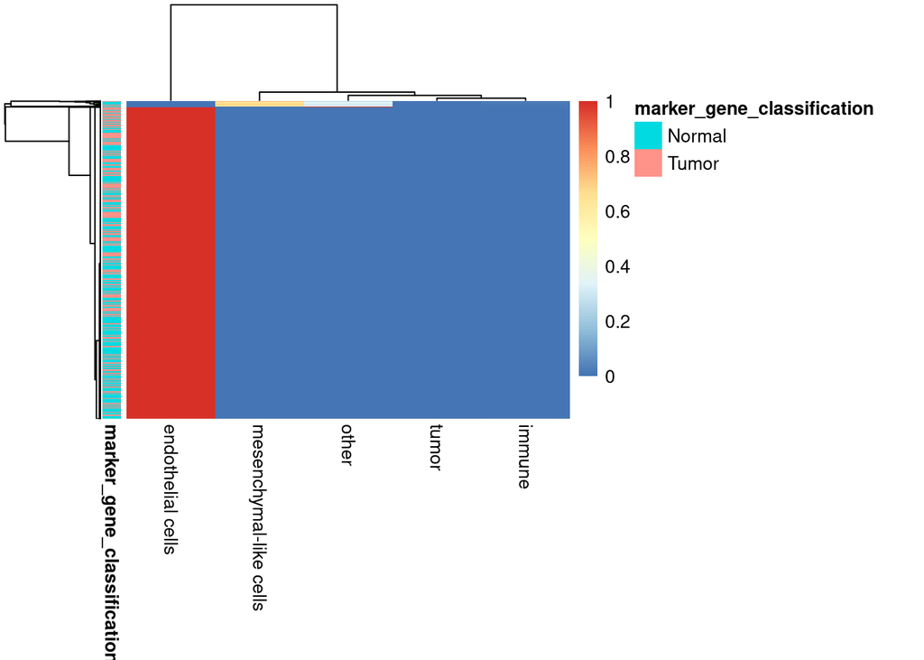

```r
# heatmap of prediction scores
visser_predictions |>
  tibble::column_to_rownames("barcode") |>
  as.matrix() |>
  pheatmap::pheatmap(show_rownames = FALSE,
                     annotation_row = annotation_df)
```

Below we will look at which cells are assigned to which cell type and then compare assignments between `CellAssign` and manual marker gene assignment.

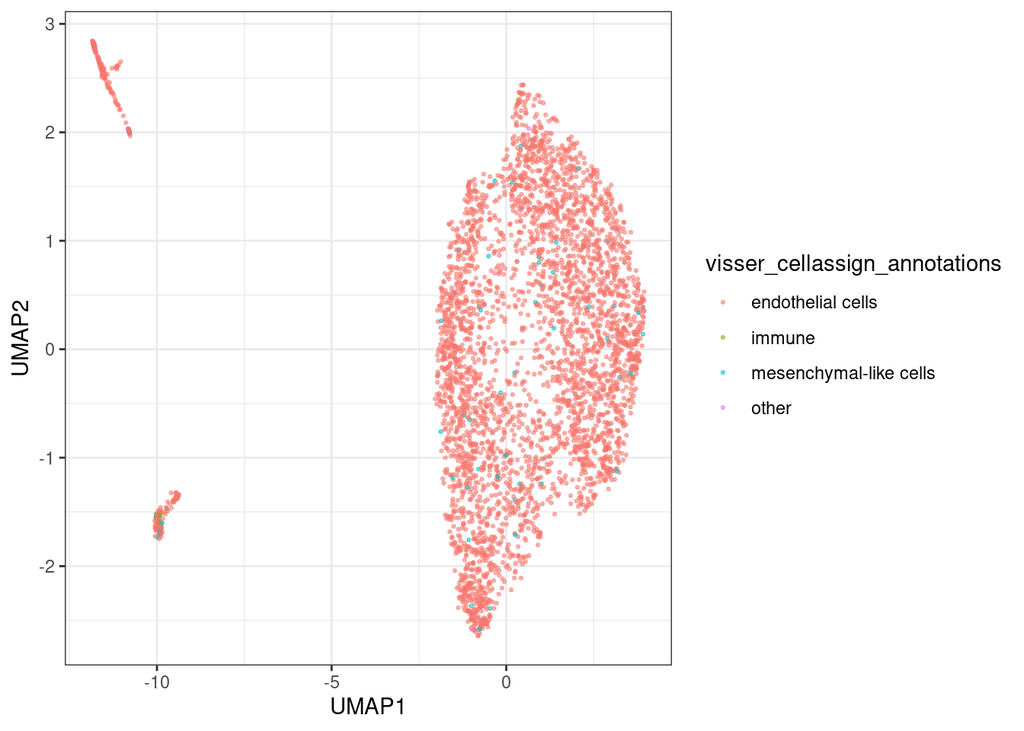

```r
# first rename column to combine with cell type df
visser_celltype_assignments <- visser_celltype_assignments |>
  dplyr::rename(visser_cellassign_annotations = celltype)

celltype_df <- celltype_df |>
  dplyr::left_join(visser_celltype_assignments, by = c("barcodes" = "barcode"))

# umap showing cell type annotations from using Visser reference
ggplot(celltype_df, aes(x = UMAP1, UMAP2, color = visser_cellassign_annotations)) +
  geom_point(size = 0.5, alpha = 0.5) +
  theme_bw()
```

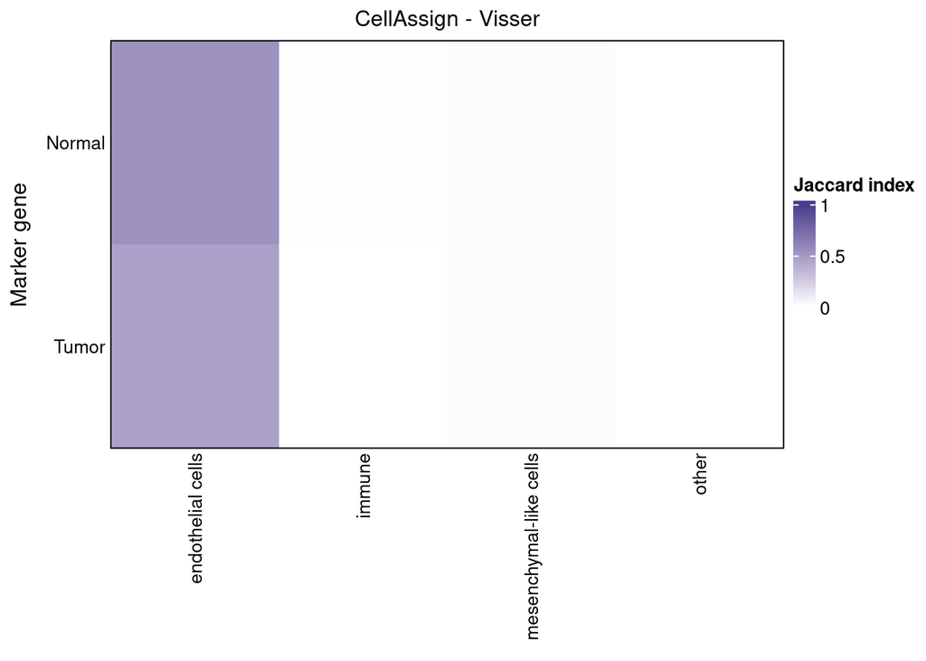

```r
# get jaccard similarity index
jaccard_mtx <- make_jaccard_matrix(celltype_df, "visser_cellassign_annotations", "marker_gene_classification")

ComplexHeatmap::Heatmap(
  t(jaccard_mtx), # transpose because matrix rows are in common & we want a vertical arrangement
  col = circlize::colorRamp2(c(0, 1), colors = c("white", "darkslateblue")),
  border = TRUE,
  ## Row parameters
  cluster_rows = FALSE,
  row_title = "Marker gene",
  row_title_gp = grid::gpar(fontsize = 12),
  row_title_side = "left",
  row_names_side = "left",
  row_dend_side = "right",
  row_names_gp = grid::gpar(fontsize = 10),
  ## Column parameters
  cluster_columns = FALSE,
  column_title = "CellAssign - Visser",
  column_title_gp = grid::gpar(fontsize = 12),
  column_names_side = "bottom",
  column_names_gp = grid::gpar(fontsize = 10),
  column_names_rot = 90,
  ## Legend parameters
  heatmap_legend_param = list(
    title = "Jaccard index",
    direction = "vertical",
    legend_width = unit(1.5, "in")
  ),
  show_heatmap_legend = TRUE,
)
```

```r
# first make sure cells have been classified as endothelial
has_endothelial <- "Endothelial cells" %in% unique(celltype_df$cellassign_celltype_annotation) &&
  "endothelial cells" %in% unique(celltype_df$visser_cellassign_annotations)

# if present, compare across both references
if(has_endothelial){
  # prep annotations for confusion matrix
  celltype_df <- celltype_df |>
    dplyr::mutate(
      caret_visser_annotations = ifelse(
        # make sure annotations match marker gene annotations
        visser_cellassign_annotations == "endothelial cells", "Endothelial cells", "Other"
      ),
      caret_cellassign_annotations = ifelse(
        cellassign_celltype_annotation == "Endothelial cells", "Endothelial cells", "Other"
      ),
      # make tumor the positive class
      caret_visser_annotations = forcats::fct_relevel(caret_visser_annotations, "Endothelial cells"),
      caret_cellassign_annotations = forcats::fct_relevel(caret_cellassign_annotations, "Endothelial cells")
    )

  caret::confusionMatrix(
    table(
      celltype_df$caret_cellassign_annotations,
      celltype_df$caret_visser_annotations)
  )
} else {
  message("No endothelial cells were classified by `CellAssign`.")
}
```

```
## No endothelial cells were classified by `CellAssign`.
```

Below, we look at the individual expression of each marker genes in the cells. These plots are grouped to show all marker genes for a given cell type in a single panel.

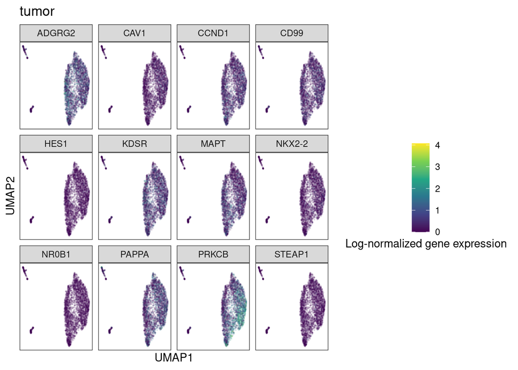

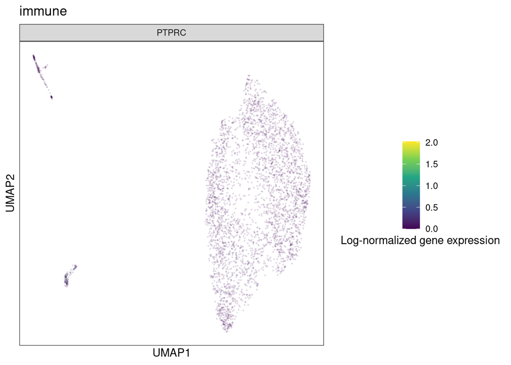

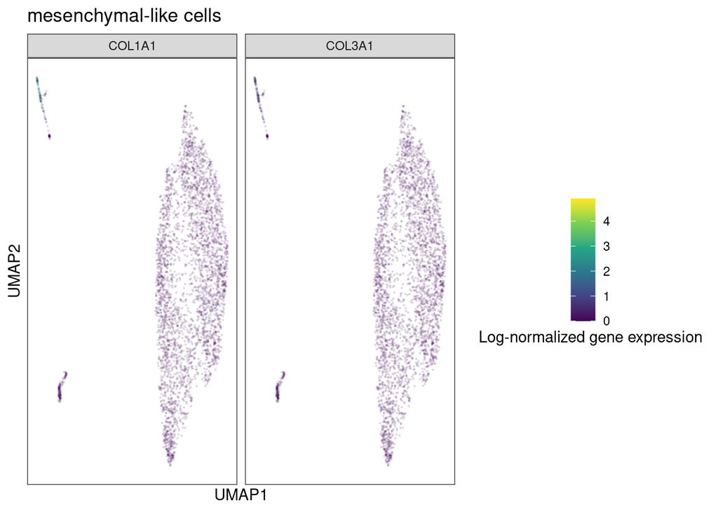

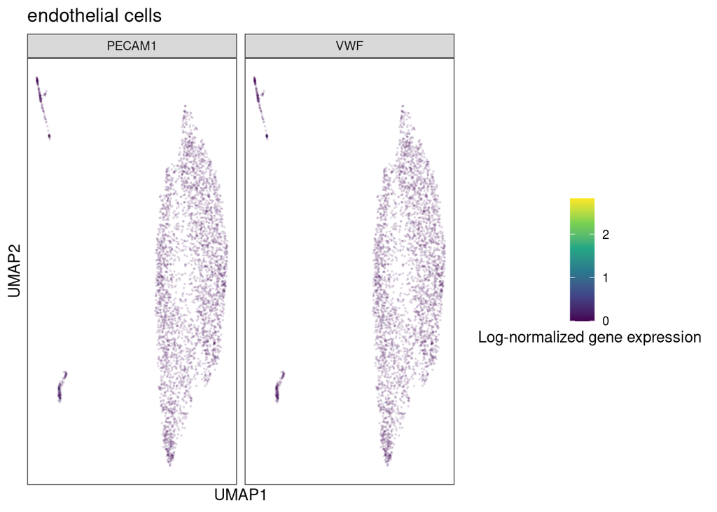

```r
# get all markers
all_markers <- visser_markers_df |>
  dplyr::pull(ensembl_gene_id)

# get expression for all markers
marker_gene_exp <- logcounts(sce[all_markers, ]) |>
  as.matrix() |>
  t() |>
  as.data.frame() |>
  tibble::rownames_to_column("barcodes")

# add in gene expression to cell type df for plotting
marker_gene_exp_df <- celltype_df |>
  dplyr::left_join(marker_gene_exp, by = "barcodes") |>
  tidyr::pivot_longer(
    cols = starts_with("ENSG"),
    names_to = "ensembl_gene_id",
    values_to = "gene_expression"
  ) |>
  dplyr::left_join(visser_markers_df)
# get a list of all celltypes in the reference
celltypes <- unique(visser_markers_df$cell_type)

# for each cell type, plot each individual marker as a UMAP
celltypes |>
  purrr::map(\(celltype){
    plot_df <- marker_gene_exp_df |>
      dplyr::filter(cell_type == celltype)

    # faceted umap showing a umap panel for each marker gene
    ggplot(plot_df, aes(x = UMAP1, y = UMAP2, color = gene_expression)) +
      geom_point(alpha = 0.1, size = 0.2) +
      facet_wrap(vars(gene_symbol)) +
      scale_color_viridis_c() +
      labs(
        title = celltype,
        color = "Log-normalized gene expression"
      ) +
      # remove axis numbers and background grid
      scale_x_continuous(labels = NULL, breaks = NULL) +
      scale_y_continuous(labels = NULL, breaks = NULL) +
      theme(
        aspect.ratio = 1,
        legend.position = "bottom",
        axis.title = element_text(size = 9, color = "black"),
        strip.text = element_text(size = 8),
        legend.title = element_text(size = 9),
        legend.text = element_text(size = 8)
      ) +
      guides(colour = guide_colorbar(title.position = "bottom", title.hjust = 0.5)) +
      theme_bw()

  })
```

Below we look at the expression of marker genes for each cell type across all cells identified to be each type by `CellAssign.` We would expect to see expression of the marker genes for tumor cells to be higher in the cells that are identified to be tumor cells compared to other cell types.

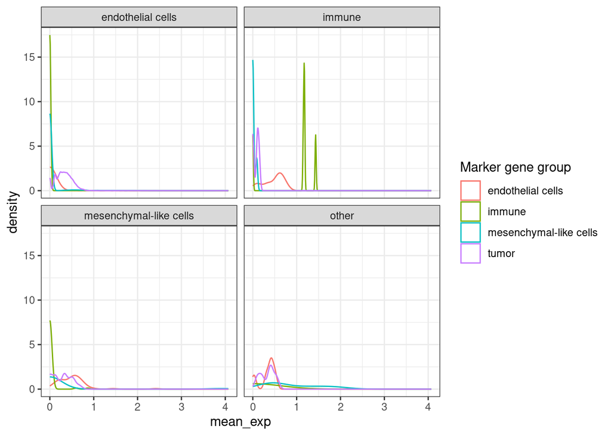

```r
grouped_celltype_df <- marker_gene_exp_df |>
  # group by barcode and cell type to get the sum
  dplyr::group_by(barcodes, cell_type) |>
  dplyr::mutate(mean_exp = mean(gene_expression))

ggplot(grouped_celltype_df, aes(x = mean_exp, color = cell_type)) +
  geom_density() +
  facet_wrap(vars(visser_cellassign_annotations)) +
  theme_bw() +
  labs(
    color = "Marker gene group"
  )
```

### Run CellAssign with markers from PanglaoDB

```r
# get cell type assignments
panglao_celltype_assignments <- get_celltype_assignment(panglao_predictions)

if(all(is.na(panglao_celltype_assignments$celltype))){
  has_panglao_assignments <- FALSE
  message("No CellAssign assignments found for tumor marker genes.")
} else {
 # create a table of assignments
  table(panglao_celltype_assignments$celltype)
  has_panglao_assignments <- TRUE
}
```

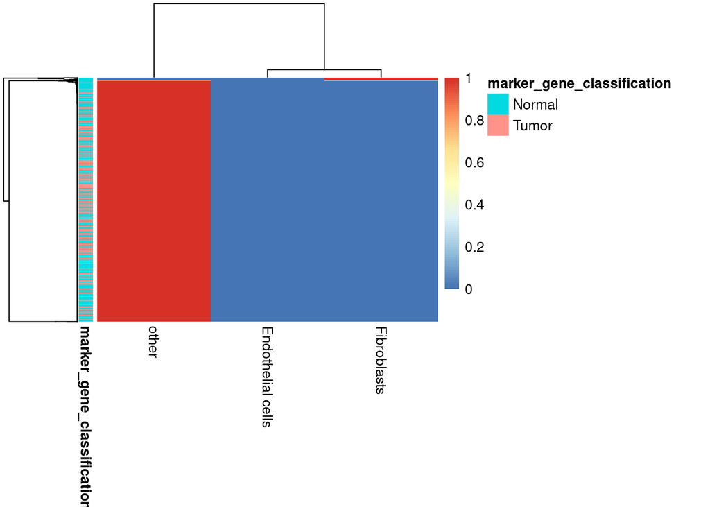

```r
# heatmap of prediction scores
panglao_predictions |>
  tibble::column_to_rownames("barcode") |>
  as.matrix() |>
  pheatmap::pheatmap(show_rownames = FALSE,
                     annotation_row = annotation_df)
```

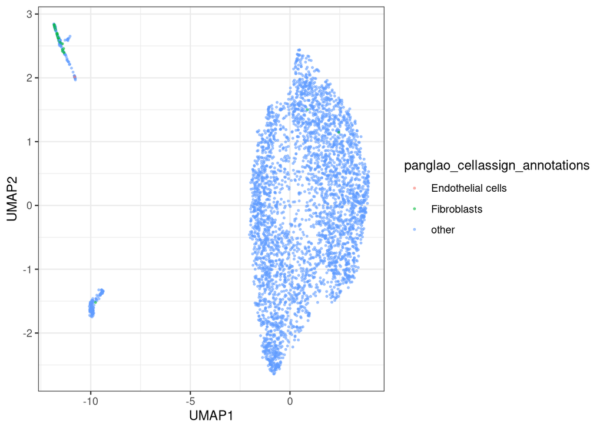

```r
# first rename column to combine with cell type df
panglao_celltype_assignments <- panglao_celltype_assignments |>
  dplyr::rename(panglao_cellassign_annotations = celltype)

celltype_df <- celltype_df |>
  dplyr::left_join(panglao_celltype_assignments, by = c("barcodes" = "barcode"))

# umap showing cell type annotations from using Visser reference
ggplot(celltype_df, aes(x = UMAP1, UMAP2, color = panglao_cellassign_annotations)) +
  geom_point(size = 0.5, alpha = 0.5) +
  theme_bw()
```

Let’s directly compare these annotations to the `CellAssign` annotations obtained from `scpca-nf`.

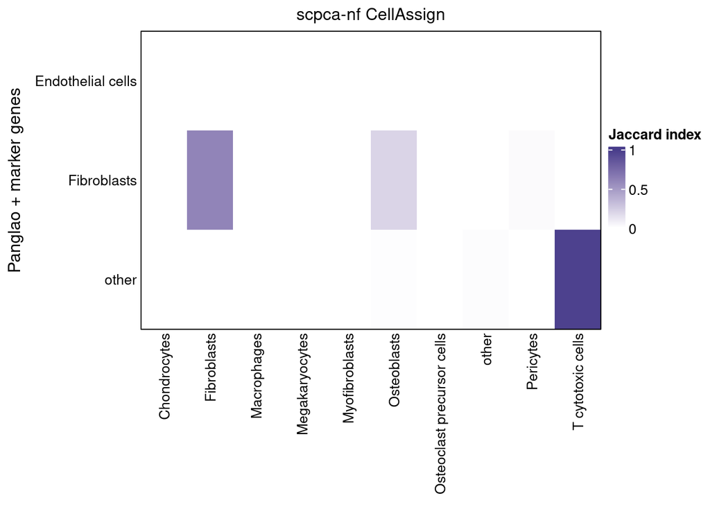

```r
# get jaccard similarity index
jaccard_mtx <- make_jaccard_matrix(celltype_df, "cellassign_celltype_annotation", "panglao_cellassign_annotations")

ComplexHeatmap::Heatmap(
  t(jaccard_mtx), # transpose because matrix rows are in common & we want a vertical arrangement
  col = circlize::colorRamp2(c(0, 1), colors = c("white", "darkslateblue")),
  border = TRUE,
  ## Row parameters
  cluster_rows = FALSE,
  row_title = "Panglao + marker genes",
  row_title_gp = grid::gpar(fontsize = 12),
  row_title_side = "left",
  row_names_side = "left",
  row_dend_side = "right",
  row_names_gp = grid::gpar(fontsize = 10),
  ## Column parameters
  cluster_columns = FALSE,
  column_title = "scpca-nf CellAssign",
  column_title_gp = grid::gpar(fontsize = 12),
  column_names_side = "bottom",
  column_names_gp = grid::gpar(fontsize = 10),
  column_names_rot = 90,
  ## Legend parameters
  heatmap_legend_param = list(
    title = "Jaccard index",
    direction = "vertical",
    legend_width = unit(1.5, "in")
  ),
  show_heatmap_legend = TRUE,
)
```

## Save annotations

```r
celltype_df <- celltype_df |>
  dplyr::select(barcodes,
                marker_gene_cellassign_annotations = cellassign_annotations,
                visser_cellassign_annotations,
                panglao_cellassign_annotations)

readr::write_tsv(celltype_df, cellassign_annotations_file)
```